# Day 14 Notebook

## Part 1

I’d love to say this was my idea, but it was not. I stole it (my code, but not my idea, not even a little, however the implementation is tortured enough that the person whose idea it was might disavow it if they ever run across this.)

Anyway - start with preparing the dish

```r
input <- read_lines("Day14Sample.txt")

dish <- data.frame(matrix(ncol=nchar(input[1]),nrow=0))

for (i in 1:length(input)){
  dish <- rbind(dish,str_split(input[i],"")[[1]])}
dish
```

| X.O. | X... | X....1 | X....2 | X....3 | X....4 | X....5 | X....6 | X....7 | X....8 |
| --- | --- | --- | --- | --- | --- | --- | --- | --- | --- |
| O | . | . | . | . | # | . | . | . | . |
| O | . | O | O | # | . | . | . | . | # |
| . | . | . | . | . | # | # | . | . | . |
| O | O | . | # | O | . | . | . | . | O |
| . | O | . | . | . | . | . | O | # | . |
| O | . | # | . | . | O | . | # | . | # |
| . | . | O | . | . | # | O | . | . | O |
| . | . | . | . | . | . | . | O | . | . |
| # | . | . | . | . | # | # | # | . | . |
| # | O | O | . | . | # | . | . | . | . |

Start with making a function that will tilt the dish north:

This basically creates a transformation matrix (showing how far to move an “O”), then a return matrix that actually moves it. The transform works by adding cumulatively adding 1 every time there’s a blank space (“.”) or resetting every time there’s a cube rock (“#”).

```r
tiltnorth <- function(d){
  ## create the baseline
  refline <- lapply(d[1,],function(x){
    if(x=="#") {0} else if(x==".") {1}else{0}})

  ## create the adder
  addit <- data.frame(matrix(nrow=(nrow(d)-1),ncol=ncol(d)))
  addit <- rbind(unlist(refline),addit)

  #  colnames(addit)<-1:(ncol(y))
  for(i in 2:nrow(d)){
    for (j in 1:ncol(d)){
      if(d[i,j]=="#"){addit[i,j]<-0
      }else if (d[i,j]=="O"){addit[i,j]<-addit[(i-1),j]
      }else if(d[i,j]=="."){addit[i,j]<-addit[(i-1),j]+1
      ### if something is wrong, just put in 34
      }else{addit[i,j]<- 34}}}


  ## create the return matrix
  returndish<-data.frame(matrix(".",ncol=ncol(d),nrow=nrow(d)))

  ## update the return matrix
  for(i in 1:nrow(d)){
    for (j in 1:ncol(d)){
      if(d[i,j]=="O"||d[i,j]=="#"){
        returndish[(i-addit[i,j]),j] <-d[i,j]}}}
  returndish}
```

running on the dish:

```r
tilteddish <-tiltnorth(dish)
tilteddish
```

| X1 | X2 | X3 | X4 | X5 | X6 | X7 | X8 | X9 | X10 |
| --- | --- | --- | --- | --- | --- | --- | --- | --- | --- |
| O | O | O | O | . | # | . | O | . | . |
| O | O | . | . | # | . | . | . | . | # |
| O | O | . | . | O | # | # | . | . | O |
| O | . | . | # | . | O | O | . | . | . |
| . | . | . | . | . | . | . | . | # | . |
| . | . | # | . | . | . | . | # | . | # |
| . | . | O | . | . | # | . | O | . | O |
| . | . | O | . | . | . | . | . | . | . |
| # | . | . | . | . | # | # | # | . | . |
| # | . | . | . | . | # | . | . | . | . |

And then a function to weigh the dish:

```r
findload<-function(d){
  rows <- nrow(d)
  dishload <- 0
  for(i in 1:rows){
    dishload<-dishload+(sum(d[i,]=="O")*(rows+1-i))}
  dishload}
```

Part 1 is findload for the tilted dish

```r
part1<-findload(tilteddish)
part1
```

```
[1] 136
```

## Part 2

So, what happens after it tilts in all four directions a billion times (really? a billion?)

First, create the functions to tilt to the east, south, and west (they all work the same as tiltnorth- then the function to run all of those in a row:

```r
tiltsouth <- function(d){
  ## create the baseline
  refline <- lapply(d[nrow(d),],function(x){
    if(x=="#") {0} else if(x==".") {1}else{0}})

  ## create the adder
  addit <- data.frame(matrix(nrow=(nrow(d)-1),ncol=ncol(d)))
  addit <- rbind(addit,unlist(refline))

  for(i in (nrow(d)-1):1){
    for (j in 1:ncol(d)){
      if(d[i,j]=="#"){addit[i,j]<-0
      }else if (d[i,j]=="O"){addit[i,j]<-addit[(i+1),j]
      }else if(d[i,j]=="."){addit[i,j]<-addit[(i+1),j]+1
      ### if something is wrong, just put in 34

      }else{addit[i,j]<- 34}}}


  ## create the return matrix
  returndish<-data.frame(matrix(".",ncol=ncol(d),nrow=nrow(d)))

  ## update the return matrix
  for(i in nrow(d):1){
    for (j in 1:ncol(d)){
      if(d[i,j]=="O"||d[i,j]=="#"){
        returndish[(i+addit[i,j]),j] <-d[i,j]}}}
  returndish}

tiltwest <- function(d){
  ## create the baseline
  refline <- lapply(d[,1],function(x){
    if(x=="#") {0} else if(x==".") {1}else{0}})

  ## create the adder
  addit <- data.frame(matrix(nrow=nrow(d),ncol=(ncol(d)-1)))
  addit <- cbind(unlist(refline),addit)

  for(j in 2:ncol(d)){
    for (i in 1:nrow(d)){
      if(d[i,j]=="#"){addit[i,j]<-0
      }else if (d[i,j]=="O"){addit[i,j]<-addit[i,(j-1)]
      }else if(d[i,j]=="."){addit[i,j]<-addit[i,(j-1)]+1
      ### if something is wrong, just put in 34
      }else{addit[i,j]<- 34}}}


  ## create the return matrix
  returndish<-data.frame(matrix(".",ncol=ncol(d),nrow=nrow(d)))

  for(j in 1:ncol(d)){
    for (i in 1:nrow(d)){
      if(d[i,j]=="O"||d[i,j]=="#"){
        returndish[i,j-addit[i,j]]<-d[i,j]}}}
  returndish}

tilteast <- function(d){
  ## create the baseline
  refline <- lapply(d[,ncol(d)],function(x){
    if(x=="#") {0} else if(x==".") {1}else{0}})

  ## create the adder
  addit <- data.frame(matrix(nrow=nrow(d),ncol=(ncol(d)-1)))
  addit <- cbind(addit,unlist(refline))

  for(j in (ncol(d)-1):1){
    for (i in 1:nrow(d)){
      if(d[i,j]=="#"){addit[i,j]<-0
      }else if (d[i,j]=="O"){addit[i,j]<-addit[i,(j+1)]
      }else if(d[i,j]=="."){addit[i,j]<-addit[i,(j+1)]+1
      ### if something is wrong, just put in 34
      }else{addit[i,j]<- 34}}}


  ## create the return matrix
  returndish<-data.frame(matrix(".",ncol=ncol(d),nrow=nrow(d)))

  for(j in ncol(d):1){
    for (i in 1:nrow(d)){
      if(d[i,j]=="O"||d[i,j]=="#"){
        returndish[i,j+addit[i,j]]<-d[i,j]}}}
  returndish}


#### to run all in a row:
spincycle<-function(d){
  go_n<-tiltnorth(d)
  go_nw<-tiltwest(go_n)
  go_nws<-tiltsouth(go_nw)
  go_nwse<-tilteast(go_nws)
  go_nwse}
```

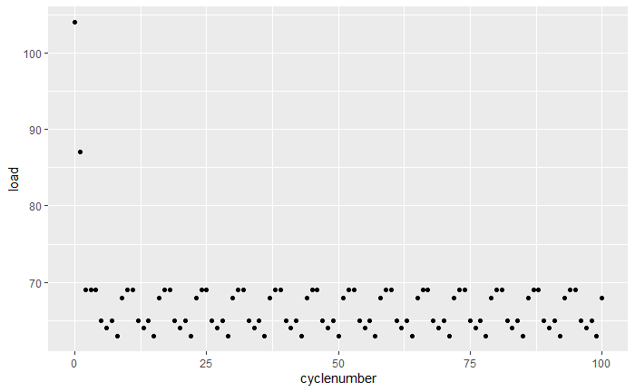

```r
gr <- ggplot(data=graphme)+
  geom_point(aes(x=cyclenumber,y=load),colour="black")
gr
```

It’s obvious there’s a repeat (for the sample, it cycles every 7.) And from there it’s trivial to figure out what the billionth repeat would look like.

Similar with the real data.